# BST.262 HW#2, ex. 3

C.V. Cosgriff

Q1. Complete, AWS screenshots in aws-setup-screnshots folder.

Q2. Complete, AWS Linux server configured with mongoDB, R, and mongolite. Screenshots in aws-setup-screnshots folder.

Q3. To programmatically retrieve the JSON files, I used bash. We can then import them trivially with mongoimport. I’ve attached a screenshot of these commands being run on AWS as well in the aws-setup-screnshots folder.

```bash
wget https://www.dropbox.com/s/3nobbupqws7llxu/heart-rate.json
wget https://www.dropbox.com/s/kpmkqyx85dugfho/step-count.json
mongoimport step-count.json --db "homework"
mongoimport heart-rate.json --db "homework"
```

Q4. Calculate the average daily heart rate and average daily step count for every participant, and then save the result to the github directory.

```r
library(mongolite)
library(dplyr)
library(lubridate)
library(ggplot2)

# Create a connection to the two mongo collections
hr_col <- mongo(db = "homework", url = "mongodb://localhost",
                collection = "heart-rate")
sc_col <- mongo(db = "homework", url = "mongodb://localhost",
                collection = "step-count")

# Then pull the data out; I like having all of the data so I can explore it with
#  dplyr as needed.
hr_q <- hr_col$find('{}')
sc_q <- sc_col$find('{}')

# Generate a data frame for the two collections; we'll need the user ID, the
# respective value of interest, and the date/time for each recording in order
# to properly merge the data.
hr_df <- data.frame(user = as.character(hr_q$header$patient_business_id),
                    hr = hr_q$body$heart_rate$value,
                    rec_date = ymd_hms(hr_q$body$effective_time_frame$time_interval$start_date_time))
sc_df <- data.frame(user = as.character(sc_q$header$patient_business_id),
                    sc = sc_q$body$step_count,
                    rec_date = ymd_hms(sc_q$body$effective_time_frame$time_interval$start_date_time))

# Finally to calculate the daily average we use dplyr to group and summarise the
# data.
hr_df_avg <- hr_df %>% mutate(day = as_date(rec_date)) %>% select(-rec_date) %>%
  group_by(user, day) %>% summarise(hr_avg = mean(hr))
sc_df_avg <- sc_df %>% mutate(day = as_date(rec_date)) %>% select(-rec_date) %>%
  group_by(user, day) %>% summarise(sc_avg = mean(sc))

# We can now join on user and the day to merge these two data sets
mhealth <- inner_join(hr_df_avg, sc_df_avg, by = c("user", "day"))

# Finally, we write the result.
write.csv(mhealth, "steps_vs_hr_avg.csv")
```

The file steps_vs_hr_avg.csv in the local directory contains the results for Q4.

Q5. Use the dataset from Q3 to generate a scatter plot comparing heart rate to step count. I believe this refers to the full dataset, not the average, and so I’ll begin with that. We can start with hr_df and sc_df in the code above, merge them by date/time and user, and then use ggplot2 to generate the plot. The requested screenshot is saved to the local directory as scatter_plot.png.

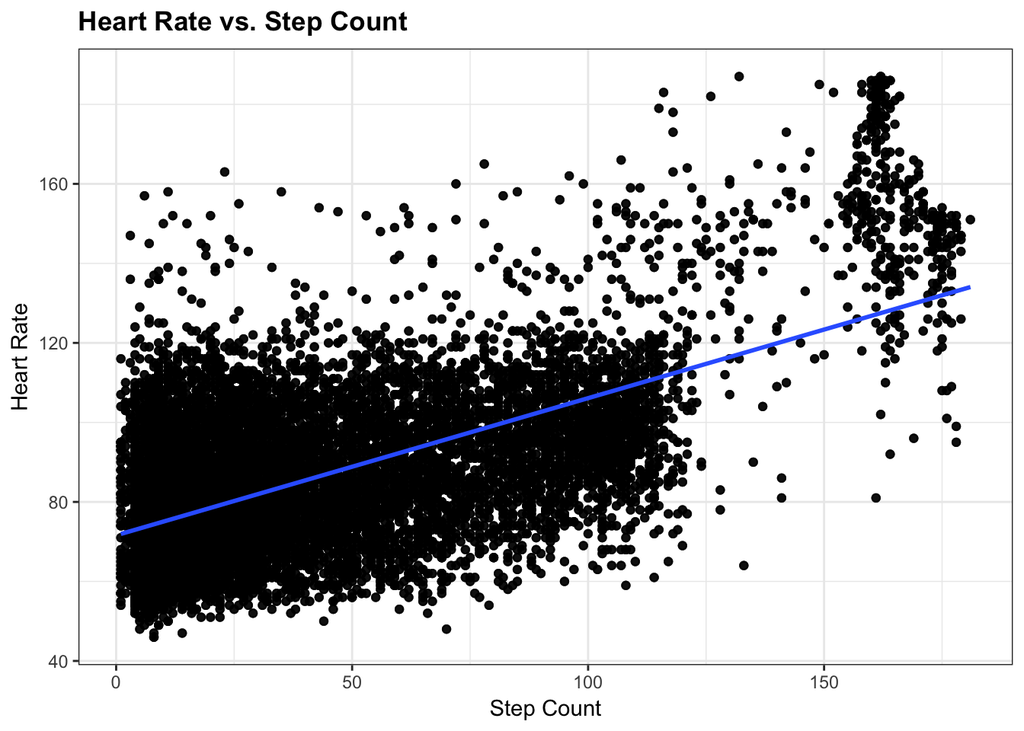

```r
hr_sc_df <- inner_join(hr_df, sc_df, by = c("user", "rec_date"))

library(dslabs) # For Rafa's theme
ds_theme_set() # Really like Rafa's minimalist theme from BST.260
ggplot(hr_sc_df) + geom_point(aes(x = sc, y = hr), alpha = 0.5) +
  geom_smooth(aes(x = sc, y = hr), method = "lm") + xlab("Step Count") +
  ylab("Heart Rate") + ggtitle("Heart Rate vs. Step Count")
```

Out of curiousity, I also generated the plot for the averages, but the correlation is less striking:

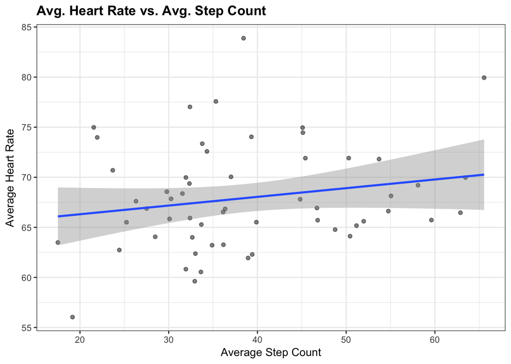

```r
library(dslabs) # For Rafa's theme
ds_theme_set() # Really like Rafa's minimalist theme from BST.260
library(ggplot2)
ggplot(mhealth) + geom_point(aes(x = sc_avg, y = hr_avg), alpha = 0.5) +
  geom_smooth(aes(x = sc_avg, y = hr_avg), method = "lm") + xlab("Average Step Count") +
  ylab("Average Heart Rate") + ggtitle("Avg. Heart Rate vs. Avg. Step Count")
```

I did not save this one to the local directory, as it was not part of the assignment.